# Analysis – Replication of Schoonvelde et al. (2019)

Colton Stevenson

April 3rd 2026

## Overview

This notebook reproduces the main analyses from:

> Schoonvelde, M., Brosius, A., & van Atteveldt, W. (2019). Liberals lecture, conservatives communicate: Analyzing complexity and ideology in 381,609 political speeches. *PLOS ONE*, 14(2), e0208450.

We replicate the descriptive statistics (Tables A.1-A.8), the four main figures, and the OLS regression tables (with and without speaker fixed effects).

**Input:** `data/cleaned/cole_final_cleaned_data.RData` (produced by `cleaning.Rmd`)

## Setup

### Libraries

```r
library(tidyverse)          # data wrangling and plotting
library(tidylog)            # verbose dplyr output
library(tidytext)           # tidy text tools
library(textdata)           # text datasets
library(quanteda)           # corpus tools
library(quanteda.textstats) # readability
library(wesanderson)        # colour palettes
library(knitr)              # table formatting
library(stringr)            # string manipulation
library(readxl)             # reading Excel files
library(cld2)               # language detection
library(DAMisc)             # summary statistics helpers
library(broom)              # tidy model output
library(patchwork)          # combining ggplots
library(stargazer)          # regression tables
```

### Load Data

```r
# Set working directory to project root
setwd(dirname(rstudioapi::getActiveDocumentContext()$path))
setwd("..")

# Load the final cleaned dataset (produced by cleaning.Rmd)
# Contains: final_data, dnk, nld_cong, ger, esp, gbr, swe, nld_parl, eus
load("data/cleaned/cole_final_cleaned_data.RData")
```

## Descriptive Statistics

These tables match the appendix tables in the original paper. Each table shows summary statistics for the five key variables across all 8 corpora.

```r
# Function to produce a summary statistics table for a given dataset
sum_stats_table <- function(df, title) {
  vars   <- c("flesch_kincaid", "left_right_scale", "lib_con_scale",
               "speech_year", "in_gov")
  labels <- c("Complexity", "Left-Right", "Progressive-Conservative",
               "Year", "In government")

  map2_dfr(vars, labels, ~ {
    x <- df[[.x]]
    tibble(
      Statistic  = .y,
      N          = format(sum(!is.na(x)), big.mark = ","),
      Mean       = round(mean(x, na.rm = TRUE), 3),
      `St. Dev.` = round(sd(x, na.rm = TRUE), 3),
      Min        = round(min(x, na.rm = TRUE), 3),
      `Pctl(25)` = round(quantile(x, .25, na.rm = TRUE), 3),
      `Pctl(75)` = round(quantile(x, .75, na.rm = TRUE), 3),
      Max        = round(max(x, na.rm = TRUE), 3)
    )
  }) |>
    kable(caption = title, align = c("l", rep("r", 7)))
}

# Generate all 8 descriptive statistics tables
dnk      |> sum_stats_table("Table A.1: Party congresses DNK")
```

Table A.1: Party congresses DNK

| Statistic | N | Mean | St. Dev. | Min | Pctl(25) | Pctl(75) | Max |
| --- | --- | --- | --- | --- | --- | --- | --- |
| Complexity | 451 | -0.045 | 1.081 | -1.793 | -0.654 | 0.379 | 11.297 |
| Left-Right | 451 | 0.926 | 1.714 | -2.915 | -0.393 | 1.950 | 4.263 |
| Progressive-Conservative | 451 | 0.302 | 1.348 | -2.148 | -0.565 | 0.837 | 4.710 |
| Year | 451 | 45.550 | 15.494 | 0.000 | 35.000 | 58.000 | 69.000 |
| In government | 451 | 0.118 | 0.322 | 0.000 | 0.000 | 0.000 | 1.000 |

```r
nld_cong |> sum_stats_table("Table A.2: Party congresses NLD")
```

Table A.2: Party congresses NLD

| Statistic | N | Mean | St. Dev. | Min | Pctl(25) | Pctl(75) | Max |
| --- | --- | --- | --- | --- | --- | --- | --- |
| Complexity | 540 | 0.038 | 0.926 | -1.913 | -0.621 | 0.653 | 3.269 |
| Left-Right | 540 | 0.872 | 0.866 | -1.784 | 0.246 | 1.455 | 3.120 |
| Progressive-Conservative | 540 | -0.515 | 0.641 | -1.867 | -0.978 | -0.110 | 2.446 |
| Year | 540 | 37.350 | 21.076 | 0.000 | 19.750 | 57.000 | 71.000 |
| In government | 540 | 0.219 | 0.414 | 0.000 | 0.000 | 0.000 | 1.000 |

```r
ger      |> sum_stats_table("Table A.3: Parliament GER")
```

Table A.3: Parliament GER

| Statistic | N | Mean | St. Dev. | Min | Pctl(25) | Pctl(75) | Max |
| --- | --- | --- | --- | --- | --- | --- | --- |
| Complexity | 61,512 | 0.121 | 0.488 | -1.866 | -0.219 | 0.426 | 4.649 |
| Left-Right | 61,512 | 1.056 | 1.123 | -0.629 | 0.152 | 2.034 | 3.391 |
| Progressive-Conservative | 61,512 | -0.313 | 0.822 | -2.435 | -0.786 | 0.117 | 1.194 |
| Year | 61,512 | 12.104 | 6.711 | 0.000 | 6.000 | 18.000 | 22.000 |
| In government | 61,512 | 0.515 | 0.500 | 0.000 | 0.000 | 1.000 | 1.000 |

```r
esp      |> sum_stats_table("Table A.4: Parliament ESP")
```

Table A.4: Parliament ESP

| Statistic | N | Mean | St. Dev. | Min | Pctl(25) | Pctl(75) | Max |
| --- | --- | --- | --- | --- | --- | --- | --- |
| Complexity | 34,622 | 2.076 | 1.007 | -0.802 | 1.378 | 2.703 | 11.900 |
| Left-Right | 34,622 | 1.099 | 0.789 | -0.400 | 0.515 | 1.659 | 2.898 |
| Progressive-Conservative | 34,622 | -0.699 | 0.551 | -2.637 | -1.182 | -0.281 | 0.162 |
| Year | 34,622 | 13.660 | 7.313 | 0.000 | 8.000 | 20.000 | 26.000 |
| In government | 34,622 | 0.346 | 0.476 | 0.000 | 0.000 | 1.000 | 1.000 |

```r
gbr      |> sum_stats_table("Table A.5: Parliament GBR")
```

Table A.5: Parliament GBR

| Statistic | N | Mean | St. Dev. | Min | Pctl(25) | Pctl(75) | Max |
| --- | --- | --- | --- | --- | --- | --- | --- |
| Complexity | 124,363 | -0.196 | 0.737 | -2.343 | -0.640 | 0.162 | 78.946 |
| Left-Right | 124,363 | 0.805 | 0.725 | -1.121 | 0.214 | 1.464 | 1.751 |
| Progressive-Conservative | 124,363 | 0.367 | 0.612 | -1.547 | 0.000 | 0.780 | 2.998 |
| Year | 124,363 | 14.226 | 7.655 | 0.000 | 8.000 | 21.000 | 27.000 |
| In government | 124,363 | 0.498 | 0.500 | 0.000 | 0.000 | 1.000 | 1.000 |

```r
swe      |> sum_stats_table("Table A.6: Parliament SWE")
```

Table A.6: Parliament SWE

| Statistic | N | Mean | St. Dev. | Min | Pctl(25) | Pctl(75) | Max |
| --- | --- | --- | --- | --- | --- | --- | --- |
| Complexity | 65,535 | -0.574 | 0.508 | -2.451 | -0.929 | -0.243 | 2.145 |
| Left-Right | 65,535 | 0.428 | 1.371 | -2.160 | -0.388 | 1.387 | 3.660 |
| Progressive-Conservative | 65,535 | -0.545 | 0.909 | -4.117 | -1.103 | 0.197 | 1.587 |
| Year | 65,535 | 13.270 | 7.258 | 0.000 | 7.000 | 19.000 | 25.000 |
| In government | 65,535 | 0.382 | 0.486 | 0.000 | 0.000 | 1.000 | 1.000 |

```r
nld_parl |> sum_stats_table("Table A.7: Parliament NLD")
```

Table A.7: Parliament NLD

| Statistic | N | Mean | St. Dev. | Min | Pctl(25) | Pctl(75) | Max |
| --- | --- | --- | --- | --- | --- | --- | --- |
| Complexity | 44,258 | -0.391 | 0.540 | -2.197 | -0.740 | -0.096 | 6.264 |
| Left-Right | 44,258 | 0.963 | 0.789 | -0.350 | 0.364 | 1.357 | 3.382 |
| Progressive-Conservative | 44,258 | 0.103 | 0.818 | -2.043 | -0.399 | 0.594 | 2.446 |
| Year | 44,258 | 11.692 | 6.100 | 0.000 | 6.000 | 17.000 | 21.000 |
| In government | 44,258 | 0.486 | 0.500 | 0.000 | 0.000 | 1.000 | 1.000 |

```r
eus      |> sum_stats_table("Table A.8: Heads of Government")
```

Table A.8: Heads of Government

| Statistic | N | Mean | St. Dev. | Min | Pctl(25) | Pctl(75) | Max |
| --- | --- | --- | --- | --- | --- | --- | --- |
| Complexity | 1,442 | 0.000 | 1.000 | -2.956 | -0.700 | 0.632 | 7.569 |
| Left-Right | 1,442 | 0.919 | 0.705 | -0.473 | 0.214 | 1.659 | 2.584 |
| Progressive-Conservative | 1,442 | -0.054 | 0.836 | -2.059 | -0.387 | 0.780 | 2.312 |
| Year | 1,442 | 4.394 | 2.469 | 0.000 | 2.000 | 7.000 | 8.000 |
| In government | 1,442 | 0.917 | 0.276 | 0.000 | 1.000 | 1.000 | 1.000 |

## Figure 1: Descriptive Information

This figure shows mean complexity scores for selected EU speakers, illustrating the the Flesch-Kincaid score’s ability to measure complexity.

```r
fig_1_rep <- eus |>
  filter(speaker %in% c("G. Brown", "D. Cameron",
                         "J.L.R. Zapatero", "M. Rajoy")) |>
  group_by(speaker) |>
  summarise(
    mean_complexity = mean(flesch_kincaid_unstand, na.rm = TRUE),
    se = sd(flesch_kincaid, na.rm = TRUE) / sqrt(n()),
    .groups = "drop"
  ) |>
  mutate(
    speaker = fct_reorder(speaker, mean_complexity),
    ideology = case_when(
      speaker %in% c("G. Brown", "J.L.R. Zapatero") ~ "Liberal",
      speaker %in% c("D. Cameron", "M. Rajoy")       ~ "Conservative"
    )
  ) |>
  ggplot(aes(x = mean_complexity, y = speaker, fill = ideology)) +
  geom_col() +
  geom_errorbar(aes(xmin = mean_complexity - 1.96 * se,
                    xmax = mean_complexity + 1.96 * se),
                width = 0.2) +
  scale_fill_manual(
    values = c("Liberal" = "#E69F00", "Conservative" = "#56B4E9"),
    name = NULL
  ) +
  labs(x = "Mean Complexity", y = NULL,
       title = "Fig 1: Descriptive information on linguistic complexity") +
  theme_minimal() +
  theme(legend.position = "bottom")
```

```
## filter: removed 216 rows (15%), 1,226 rows remaining
## group_by: one grouping variable (speaker)
## summarise: now 4 rows and 3 columns, ungrouped
## mutate: converted 'speaker' from character to factor (0 new NA)
##         new variable 'ideology' (character) with 2 unique values and 0% NA
```

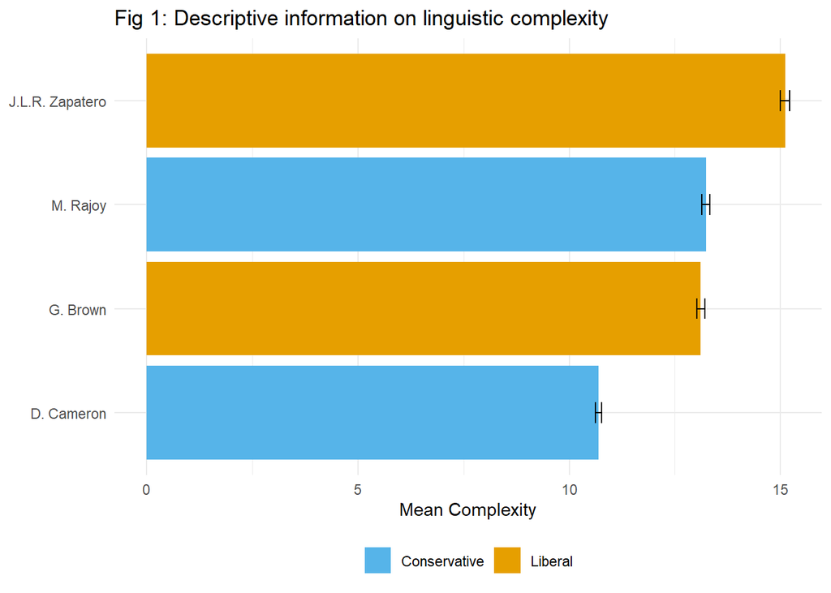

```r
fig_1_rep
```

```r
# Save figure
ggsave("../figures/cole-fig-1.png", fig_1_rep, width = 8, height = 5)
```

## Figure 2: Effect of Ideology on Complexity

This replicates the paper’s main result figure. For each of the 8 corpora, we run an OLS regression of standardized FK scores on standardized ideology (lib-con and left-right), year, and governing party status, then plot the coefficients with 95% confidence intervals.

```r
# Define all 8 datasets
datasets <- list(
  "Parliament GER"         = ger,
  "Parliament ESP"         = esp,
  "Parliament GBR"         = gbr,
  "Parliament SWE"         = swe,
  "Parliament NLD"         = nld_parl,
  "Party congresses DNK"   = dnk,
  "Party congresses NLD"   = nld_cong,
  "Heads of Government"    = eus
)

# Run OLS for each dataset, extract ideology coefficients
results <- map_dfr(names(datasets), function(name) {
  df <- datasets[[name]] |>
    mutate(across(c(flesch_kincaid, lib_con_scale,
                    left_right_scale, speech_year), scale))

  model <- lm(flesch_kincaid ~ lib_con_scale + left_right_scale +
               speech_year + in_gov, data = df)

  tidy(model, conf.int = TRUE) |>
    filter(term %in% c("lib_con_scale", "left_right_scale")) |>
    mutate(dataset = name)
})
```

```
## mutate: changed 61,512 values (100%) of 'speech_year' (0 new NAs)
##         changed 61,512 values (100%) of 'lib_con_scale' (0 new NAs)
##         changed 61,512 values (100%) of 'left_right_scale' (0 new NAs)
##         changed 61,512 values (100%) of 'flesch_kincaid' (0 new NAs)
## filter: removed 3 rows (60%), 2 rows remaining
## mutate: new variable 'dataset' (character) with one unique value and 0% NA
## mutate: changed 34,622 values (100%) of 'speech_year' (0 new NAs)
##         changed 34,622 values (100%) of 'lib_con_scale' (0 new NAs)
##         changed 34,622 values (100%) of 'left_right_scale' (0 new NAs)
##         changed 34,622 values (100%) of 'flesch_kincaid' (0 new NAs)
## filter: removed 3 rows (60%), 2 rows remaining
## mutate: new variable 'dataset' (character) with one unique value and 0% NA
## mutate: changed 124,363 values (100%) of 'speech_year' (0 new NAs)
##         changed 124,363 values (100%) of 'lib_con_scale' (0 new NAs)
##         changed 124,363 values (100%) of 'left_right_scale' (0 new NAs)
##         changed 124,363 values (100%) of 'flesch_kincaid' (0 new NAs)
## filter: removed 3 rows (60%), 2 rows remaining
## mutate: new variable 'dataset' (character) with one unique value and 0% NA
## mutate: changed 65,535 values (100%) of 'speech_year' (0 new NAs)
##         changed 65,535 values (100%) of 'lib_con_scale' (0 new NAs)
##         changed 65,535 values (100%) of 'left_right_scale' (0 new NAs)
##         changed 65,535 values (100%) of 'flesch_kincaid' (0 new NAs)
## filter: removed 3 rows (60%), 2 rows remaining
## mutate: new variable 'dataset' (character) with one unique value and 0% NA
## mutate: changed 44,258 values (100%) of 'speech_year' (0 new NAs)
##         changed 44,258 values (100%) of 'lib_con_scale' (0 new NAs)
##         changed 44,258 values (100%) of 'left_right_scale' (0 new NAs)
##         changed 44,258 values (100%) of 'flesch_kincaid' (0 new NAs)
## filter: removed 3 rows (60%), 2 rows remaining
## mutate: new variable 'dataset' (character) with one unique value and 0% NA
## mutate: changed 451 values (100%) of 'speech_year' (0 new NAs)
##         changed 451 values (100%) of 'lib_con_scale' (0 new NAs)
##         changed 451 values (100%) of 'left_right_scale' (0 new NAs)
##         changed 451 values (100%) of 'flesch_kincaid' (0 new NAs)
## filter: removed 3 rows (60%), 2 rows remaining
## mutate: new variable 'dataset' (character) with one unique value and 0% NA
## mutate: changed 540 values (100%) of 'speech_year' (0 new NAs)
##         changed 540 values (100%) of 'lib_con_scale' (0 new NAs)
##         changed 540 values (100%) of 'left_right_scale' (0 new NAs)
##         changed 540 values (100%) of 'flesch_kincaid' (0 new NAs)
## filter: removed 3 rows (60%), 2 rows remaining
## mutate: new variable 'dataset' (character) with one unique value and 0% NA
## mutate: changed 1,442 values (100%) of 'speech_year' (0 new NAs)
##         changed 1,442 values (100%) of 'lib_con_scale' (0 new NAs)
##         changed 1,442 values (100%) of 'left_right_scale' (0 new NAs)
##         changed 1,387 values (96%) of 'flesch_kincaid' (0 new NAs)
## filter: removed 3 rows (60%), 2 rows remaining
## mutate: new variable 'dataset' (character) with one unique value and 0% NA
```

```r
# Add panel grouping for faceting (Parliament vs Congress/HoG)
results <- results |>
  mutate(
    panel = ifelse(str_detect(dataset, "Parliament"),
                   "Parliament", "Congress and Heads of Government"),
    panel = factor(panel,
                   levels = c("Parliament", "Congress and Heads of Government")),
    dataset = factor(dataset, levels = rev(c(
      "Parliament GER", "Parliament ESP", "Parliament GBR",
      "Parliament SWE", "Parliament NLD",
      "Party congresses DNK", "Party congresses NLD", "Heads of Government"
    )))
  )
```

```
## mutate: converted 'dataset' from character to factor (0 new NA)
##         new variable 'panel' (factor) with 2 unique values and 0% NA
```

```r
# Panel a: Liberal-Conservative ideology effect
p2a <- results |>
  filter(term == "lib_con_scale") |>
  ggplot(aes(x = estimate, y = dataset)) +
  geom_point() +
  geom_errorbarh(aes(xmin = conf.low, xmax = conf.high), height = 0.2) +
  geom_vline(xintercept = 0, linetype = "dashed") +
  facet_wrap(~panel, scales = "free_y", ncol = 1) +
  labs(x = "Effect of lib-cons ideology", y = NULL, title = "a") +
  theme_minimal()
```

```
## filter: removed 8 rows (50%), 8 rows remaining
```

```r
# Panel b: Left-Right ideology effect
p2b <- results |>
  filter(term == "left_right_scale") |>
  ggplot(aes(x = estimate, y = dataset)) +
  geom_point() +
  geom_errorbarh(aes(xmin = conf.low, xmax = conf.high), height = 0.2) +
  geom_vline(xintercept = 0, linetype = "dashed") +
  facet_wrap(~panel, scales = "free_y", ncol = 1) +
  labs(x = "Effect of left-right ideology", y = NULL, title = "b") +
  theme_minimal()
```

```
## filter: removed 8 rows (50%), 8 rows remaining
```

```
## `height` was translated to `width`.
## `height` was translated to `width`.
```

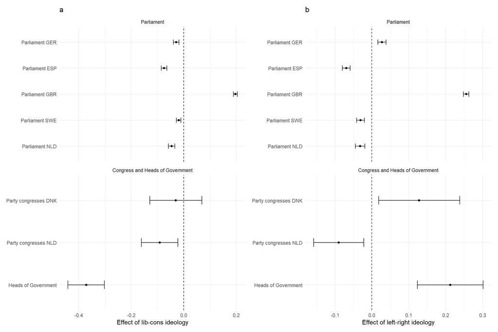

```r
fig_2_plot <- p2a + p2b
fig_2_plot
```

```r
ggsave("../figures/cole-fig-2.png", fig_2_plot, width = 12, height = 8)
```

```
## `height` was translated to `width`.
## `height` was translated to `width`.
```

## Figure 3: Complexity Over Time

This figure shows smoothed trends in speech complexity over time, separately for parliamentary speeches and party congress speeches.

```r
# Panel a: Parliamentary speeches (5 countries)
p3a <- bind_rows(
  esp      |> mutate(corpus = "ESP"),
  gbr      |> mutate(corpus = "GBR"),
  ger      |> mutate(corpus = "GER"),
  nld_parl |> mutate(corpus = "NLD"),
  swe      |> mutate(corpus = "SWE")
) |>
  mutate(
    corpus = factor(corpus, levels = c("ESP", "GBR", "GER", "NLD", "SWE")),
    year = speech_year + 1988  # convert zero-based year back to calendar year
  ) |>
  ggplot(aes(x = year, y = flesch_kincaid_unstand)) +
  geom_smooth(method = "loess", se = FALSE, color = "red", span = 0.5) +
  facet_wrap(~corpus, nrow = 1, scales = "free_x") +
  scale_x_continuous(breaks = c(1990, 2000, 2010),
                     labels = c("'90", "'00", "'10")) +
  labs(x = NULL, y = "Complexity", title = "a") +
  theme_minimal() +
  theme(panel.grid.minor = element_blank())
```

```
## mutate: new variable 'corpus' (character) with one unique value and 0% NA
## mutate: new variable 'corpus' (character) with one unique value and 0% NA
## mutate: new variable 'corpus' (character) with one unique value and 0% NA
## mutate: new variable 'corpus' (character) with one unique value and 0% NA
## mutate: new variable 'corpus' (character) with one unique value and 0% NA
## mutate: converted 'corpus' from character to factor (0 new NA)
##         new variable 'year' (double) with 28 unique values and 0% NA
```

```r
# Panel b: Party congress speeches (Denmark and Netherlands)
p3b <- bind_rows(
  dnk      |> mutate(corpus = "DNK"),
  nld_cong |> mutate(corpus = "NLD")
) |>
  mutate(
    corpus = factor(corpus, levels = c("DNK", "NLD")),
    year = speech_year + 1944  # convert zero-based year back to calendar year
  ) |>
  ggplot(aes(x = year, y = flesch_kincaid_unstand)) +
  geom_smooth(method = "loess", se = FALSE, color = "red", span = 0.5) +
  facet_wrap(~corpus, nrow = 1, scales = "free_x") +
  scale_x_continuous(breaks = c(1960, 1980, 2000),
                     labels = c("'60", "'80", "'00")) +
  labs(x = NULL, y = "Complexity", title = "b") +
  theme_minimal() +
  theme(panel.grid.minor = element_blank())
```

```
## mutate: new variable 'corpus' (character) with one unique value and 0% NA
## mutate: new variable 'corpus' (character) with one unique value and 0% NA
## mutate: converted 'corpus' from character to factor (0 new NA)
##         new variable 'year' (double) with 72 unique values and 0% NA
```

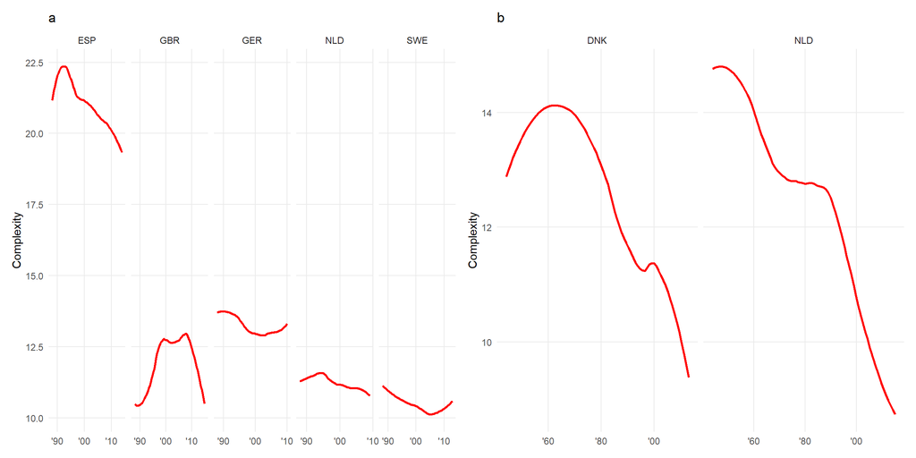

```r
fig_3_plot <- p3a + p3b
fig_3_plot
```

```r
ggsave("../figures/cole-fig-3.png", fig_3_plot, width = 12, height = 6)
```

## Figure 4: Party Fixed Effects

Panel (a) shows OLS coefficients for the effect of conservatism with party fixed effects included. Panel (b) shows within-party loess trends for ideology and complexity over time for two illustrative parties.

```r
# --- Panel a: Party fixed effects (excluding EUSpeech) ---
datasets_noeus <- list(
  "Parliament GER"       = ger,
  "Parliament ESP"       = esp,
  "Parliament GBR"       = gbr,
  "Parliament SWE"       = swe,
  "Parliament NLD"       = nld_parl,
  "Party congresses DNK" = dnk,
  "Party congresses NLD" = nld_cong
)

# Run OLS with party FE for each corpus
results_fe <- map_dfr(names(datasets_noeus), function(name) {
  df <- datasets_noeus[[name]] |>
    mutate(across(c(flesch_kincaid, lib_con_scale,
                    left_right_scale, speech_year), scale))

  model <- lm(flesch_kincaid ~ lib_con_scale + left_right_scale +
               speech_year + in_gov + factor(party), data = df)

  tidy(model, conf.int = TRUE) |>
    filter(term == "lib_con_scale") |>
    mutate(dataset = name)
})
```

```
## mutate: changed 61,512 values (100%) of 'speech_year' (0 new NAs)
##         changed 61,512 values (100%) of 'lib_con_scale' (0 new NAs)
##         changed 61,512 values (100%) of 'left_right_scale' (0 new NAs)
##         changed 61,512 values (100%) of 'flesch_kincaid' (0 new NAs)
## filter: removed 9 rows (90%), one row remaining
## mutate: new variable 'dataset' (character) with one unique value and 0% NA
## mutate: changed 34,622 values (100%) of 'speech_year' (0 new NAs)
##         changed 34,622 values (100%) of 'lib_con_scale' (0 new NAs)
##         changed 34,622 values (100%) of 'left_right_scale' (0 new NAs)
##         changed 34,622 values (100%) of 'flesch_kincaid' (0 new NAs)
## filter: removed 14 rows (93%), one row remaining
## mutate: new variable 'dataset' (character) with one unique value and 0% NA
## mutate: changed 124,363 values (100%) of 'speech_year' (0 new NAs)
##         changed 124,363 values (100%) of 'lib_con_scale' (0 new NAs)
##         changed 124,363 values (100%) of 'left_right_scale' (0 new NAs)
##         changed 124,363 values (100%) of 'flesch_kincaid' (0 new NAs)
## filter: removed 11 rows (92%), one row remaining
## mutate: new variable 'dataset' (character) with one unique value and 0% NA
## mutate: changed 65,535 values (100%) of 'speech_year' (0 new NAs)
##         changed 65,535 values (100%) of 'lib_con_scale' (0 new NAs)
##         changed 65,535 values (100%) of 'left_right_scale' (0 new NAs)
##         changed 65,535 values (100%) of 'flesch_kincaid' (0 new NAs)
## filter: removed 12 rows (92%), one row remaining
## mutate: new variable 'dataset' (character) with one unique value and 0% NA
## mutate: changed 44,258 values (100%) of 'speech_year' (0 new NAs)
##         changed 44,258 values (100%) of 'lib_con_scale' (0 new NAs)
##         changed 44,258 values (100%) of 'left_right_scale' (0 new NAs)
##         changed 44,258 values (100%) of 'flesch_kincaid' (0 new NAs)
## filter: removed 16 rows (94%), one row remaining
## mutate: new variable 'dataset' (character) with one unique value and 0% NA
## mutate: changed 451 values (100%) of 'speech_year' (0 new NAs)
##         changed 451 values (100%) of 'lib_con_scale' (0 new NAs)
##         changed 451 values (100%) of 'left_right_scale' (0 new NAs)
##         changed 451 values (100%) of 'flesch_kincaid' (0 new NAs)
## filter: removed 8 rows (89%), one row remaining
## mutate: new variable 'dataset' (character) with one unique value and 0% NA
## mutate: changed 540 values (100%) of 'speech_year' (0 new NAs)
##         changed 540 values (100%) of 'lib_con_scale' (0 new NAs)
##         changed 540 values (100%) of 'left_right_scale' (0 new NAs)
##         changed 540 values (100%) of 'flesch_kincaid' (0 new NAs)
## filter: removed 10 rows (91%), one row remaining
## mutate: new variable 'dataset' (character) with one unique value and 0% NA
```

```r
results_fe <- results_fe |>
  mutate(
    panel = ifelse(str_detect(dataset, "Parliament"), "Parliament", "Congress"),
    panel = factor(panel, levels = c("Parliament", "Congress")),
    dataset = factor(dataset, levels = rev(c(
      "Parliament GER", "Parliament ESP", "Parliament GBR",
      "Parliament SWE", "Parliament NLD",
      "Party congresses DNK", "Party congresses NLD"
    )))
  )
```

```
## mutate: converted 'dataset' from character to factor (0 new NA)
##         new variable 'panel' (factor) with 2 unique values and 0% NA
```

```r
p4a <- results_fe |>
  ggplot(aes(x = estimate, y = dataset)) +
  geom_point() +
  geom_errorbarh(aes(xmin = conf.low, xmax = conf.high), height = 0.2) +
  geom_vline(xintercept = 0, linetype = "solid") +
  facet_wrap(~panel, scales = "free_y", ncol = 1) +
  labs(x = "Fixed effect of conservatism", y = NULL, title = "a") +
  theme_minimal()

# --- Panel b: Within-party trends (SD in Denmark, VVD in Netherlands) ---
sd_data <- dnk |>
  filter(party == "SD") |>
  mutate(
    year       = speech_year + 1944,
    complexity = scale(flesch_kincaid)[, 1],
    ideology   = scale(lib_con_scale)[, 1]
  ) |>
  select(year, complexity, ideology) |>
  pivot_longer(c(complexity, ideology),
               names_to = "variable", values_to = "value") |>
  mutate(corpus = "Social Democratic Party\n(DK)")
```

```
## filter: removed 258 rows (57%), 193 rows remaining
## mutate: new variable 'year' (double) with 29 unique values and 0% NA
##         new variable 'complexity' (double) with 193 unique values and 0% NA
##         new variable 'ideology' (double) with 18 unique values and 0% NA
## select: dropped 14 variables (speech_year, speech_month, text, speaker, party, …)
## pivot_longer: reorganized (complexity, ideology) into (variable, value) [was 193x3, now 386x3]
## mutate: new variable 'corpus' (character) with one unique value and 0% NA
```

```r
vvd_data <- nld_cong |>
  filter(party == "VVD") |>
  mutate(
    year       = speech_year + 1944,
    complexity = scale(flesch_kincaid)[, 1],
    ideology   = scale(lib_con_scale)[, 1]
  ) |>
  select(year, complexity, ideology) |>
  pivot_longer(c(complexity, ideology),
               names_to = "variable", values_to = "value") |>
  mutate(corpus = "Liberal Party\n(NL)")
```

```
## filter: removed 452 rows (84%), 88 rows remaining
## mutate: new variable 'year' (double) with 39 unique values and 0% NA
##         new variable 'complexity' (double) with 88 unique values and 0% NA
##         new variable 'ideology' (double) with 19 unique values and 0% NA
## select: dropped 14 variables (speech_year, speech_month, text, speaker, party, …)
## pivot_longer: reorganized (complexity, ideology) into (variable, value) [was 88x3, now 176x3]
## mutate: new variable 'corpus' (character) with one unique value and 0% NA
```

```r
p4b <- bind_rows(sd_data, vvd_data) |>
  mutate(corpus = factor(corpus,
    levels = c("Social Democratic Party\n(DK)", "Liberal Party\n(NL)")
  )) |>
  ggplot(aes(x = year, y = value, color = variable)) +
  geom_smooth(method = "loess", se = FALSE, span = 0.5) +
  facet_wrap(~corpus, ncol = 1) +
  scale_color_manual(values = c("complexity" = "blue", "ideology" = "red")) +
  labs(x = NULL, y = "Standardized values", color = NULL, title = "b") +
  theme_minimal() +
  theme(legend.position = "bottom",
        strip.text.y = element_text(angle = 0))
```

```
## mutate: converted 'corpus' from character to factor (0 new NA)
```

```
## `height` was translated to `width`.
```

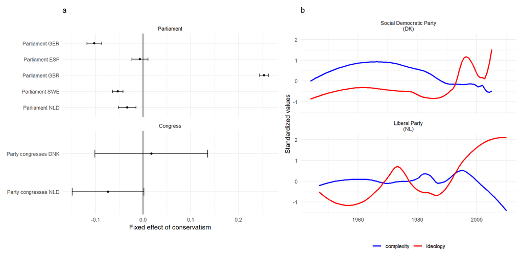

```r
fig_4_plot <- p4a + p4b
fig_4_plot
```

```r
ggsave("../figures/cole-fig-4.png", fig_4_plot, width = 12, height = 6)
```

```
## `height` was translated to `width`.
```

## OLS Regression Tables

### Standard OLS (No Fixed Effects)

These models regress standardized Flesch-Kincaid scores on ideology (left-right and lib-con), year, and governing party status. The EUSpeech model excludes year and governing status due to the smaller sample of heads of government.

```r
m_dnk      <- lm(flesch_kincaid ~ left_right_scale + lib_con_scale +
                  speech_year + in_gov, data = dnk)
m_nld_cong <- lm(flesch_kincaid ~ left_right_scale + lib_con_scale +
                  speech_year + in_gov, data = nld_cong)
m_ger      <- lm(flesch_kincaid ~ left_right_scale + lib_con_scale +
                  speech_year + in_gov, data = ger)
m_esp      <- lm(flesch_kincaid ~ left_right_scale + lib_con_scale +
                  speech_year + in_gov, data = esp)
m_gbr      <- lm(flesch_kincaid ~ left_right_scale + lib_con_scale +
                  speech_year + in_gov, data = gbr)
m_swe      <- lm(flesch_kincaid ~ left_right_scale + lib_con_scale +
                  speech_year + in_gov, data = swe)
m_nld_parl <- lm(flesch_kincaid ~ left_right_scale + lib_con_scale +
                  speech_year + in_gov, data = nld_parl)
m_eus      <- lm(flesch_kincaid ~ left_right_scale + lib_con_scale,
                  data = eus)

stargazer(m_dnk, m_nld_cong, m_ger, m_esp,
          title = "Table C.1: OLS regression results",
          column.labels = c("DNK Congress", "NLD Congress",
                            "GER Parl", "ESP Parl"),
          covariate.labels = c("Left-Right", "Progressive-Conservative",
                               "Year", "In government"),
          type = "html",
          star.cutoffs = c(0.1, 0.05, 0.01))
```

**Table C.1: OLS regression results**

|  | *Dependent variable:* |  |  |  |
| --- | --- | --- | --- | --- |
|  | flesch_kincaid |  |  |  |
|  | DNK Congress | NLD Congress | GER Parl | ESP Parl |
|  | (1) | (2) | (3) | (4) |
| Left-Right | 0.081** | -0.096*** | 0.012*** | -0.089*** |
|  | (0.035) | (0.037) | (0.003) | (0.007) |
| Progressive-Conservative | -0.024 | -0.133*** | -0.017*** | -0.137*** |
|  | (0.041) | (0.051) | (0.003) | (0.010) |
| Year | -0.031*** | -0.029*** | -0.007*** | -0.028*** |
|  | (0.004) | (0.002) | (0.0003) | (0.001) |
| In government | 0.085 | 0.088 | 0.033*** | -0.050*** |
|  | (0.150) | (0.085) | (0.004) | (0.011) |
| Constant | 1.267*** | 1.106*** | 0.176*** | 2.471*** |
|  | (0.157) | (0.072) | (0.006) | (0.015) |
| Observations | 451 | 540 | 61,512 | 34,622 |
| R<sup>2</sup> | 0.162 | 0.451 | 0.016 | 0.053 |
| Adjusted R<sup>2</sup> | 0.154 | 0.447 | 0.016 | 0.053 |
| Residual Std. Error | 0.994 (df = 446) | 0.689 (df = 535) | 0.484 (df = 61507) | 0.980 (df = 34617) |
| F Statistic | 21.520*** (df = 4; 446) | 109.809*** (df = 4; 535) | 246.915*** (df = 4; 61507) | 482.809*** (df = 4; 34617) |
| *Note:* | p<0.1; p<0.05; p<0.01 |  |  |  |

```r
stargazer(m_gbr, m_swe, m_nld_parl, m_eus,
          title = "Table C.1 continued",
          column.labels = c("GBR Parl", "SWE Parl", "NLD Parl", "PM"),
          covariate.labels = c("Left-Right", "Progressive-Conservative",
                               "Year", "In government"),
          type = "html",
          star.cutoffs = c(0.1, 0.05, 0.01))
```

**Table C.1 continued**

|  | *Dependent variable:* |  |  |  |
| --- | --- | --- | --- | --- |
|  | flesch_kincaid |  |  |  |
|  | GBR Parl | SWE Parl | NLD Parl | PM |
|  | (1) | (2) | (3) | (4) |
| Left-Right | 0.259*** | -0.011*** | -0.022*** | 0.246*** |
|  | (0.004) | (0.002) | (0.004) | (0.049) |
| Progressive-Conservative | 0.237*** | -0.011*** | -0.031*** | -0.432*** |
|  | (0.004) | (0.003) | (0.004) | (0.041) |
| Year | 0.006*** | -0.005*** | -0.008*** |  |
|  | (0.0003) | (0.0004) | (0.0004) |  |
| In government | -0.022*** | 0.087*** | -0.033*** |  |
|  | (0.004) | (0.004) | (0.006) |  |
| Constant | -0.569*** | -0.538*** | -0.263*** | -0.249*** |
|  | (0.006) | (0.006) | (0.008) | (0.049) |
| Observations | 124,363 | 65,535 | 44,258 | 1,442 |
| R<sup>2</sup> | 0.056 | 0.018 | 0.010 | 0.255 |
| Adjusted R<sup>2</sup> | 0.056 | 0.018 | 0.010 | 0.254 |
| Residual Std. Error | 0.716 (df = 124358) | 0.504 (df = 65530) | 0.538 (df = 44253) | 0.864 (df = 1439) |
| F Statistic | 1,828.630*** (df = 4; 124358) | 293.173*** (df = 4; 65530) | 112.871*** (df = 4; 44253) | 245.690*** (df = 2; 1439) |
| *Note:* | p<0.1; p<0.05; p<0.01 |  |  |  |

### Speaker Fixed Effects

These models add speaker fixed effects to control for individual speaking styles. This tests whether the ideology-complexity relationship holds *within speakers* as their party’s ideology shifts.

```r
m_dnk_fe      <- lm(flesch_kincaid ~ left_right_scale + lib_con_scale +
                     speech_year + in_gov + factor(speaker), data = dnk)
m_nld_cong_fe <- lm(flesch_kincaid ~ left_right_scale + lib_con_scale +
                     speech_year + in_gov + factor(speaker), data = nld_cong)
m_ger_fe      <- lm(flesch_kincaid ~ left_right_scale + lib_con_scale +
                     speech_year + in_gov + factor(speaker), data = ger)
m_esp_fe      <- lm(flesch_kincaid ~ left_right_scale + lib_con_scale +
                     speech_year + in_gov + factor(speaker), data = esp)
m_gbr_fe      <- lm(flesch_kincaid ~ left_right_scale + lib_con_scale +
                     speech_year + in_gov + factor(speaker), data = gbr)
m_swe_fe      <- lm(flesch_kincaid ~ left_right_scale + lib_con_scale +
                     speech_year + in_gov + factor(speaker), data = swe)
m_nld_parl_fe <- lm(flesch_kincaid ~ left_right_scale + lib_con_scale +
                     speech_year + in_gov + factor(speaker), data = nld_parl)

stargazer(m_dnk_fe, m_nld_cong_fe, m_ger_fe, m_esp_fe,
          title = "Table D.1: Speaker fixed effects regression results",
          column.labels = c("DNK Congress", "NLD Congress",
                            "GER Parl", "ESP Parl"),
          covariate.labels = c("Left-Right", "Progressive-Conservative",
                               "Year", "In government"),
          omit = "factor\\(speaker\\)",
          add.lines = list(c("Speaker Fixed Effects?",
                             "Yes", "Yes", "Yes", "Yes")),
          type = "html",
          star.cutoffs = c(0.1, 0.05, 0.01))
```

**Table D.1: Speaker fixed effects regression results**

|  | *Dependent variable:* |  |  |  |
| --- | --- | --- | --- | --- |
|  | flesch_kincaid |  |  |  |
|  | DNK Congress | NLD Congress | GER Parl | ESP Parl |
|  | (1) | (2) | (3) | (4) |
| Left-Right | 0.049 | 0.080 | -0.022*** | 0.018 |
|  | (0.056) | (0.066) | (0.005) | (0.017) |
| Progressive-Conservative | 0.012 | 0.036 | -0.056*** | -0.053*** |
|  | (0.052) | (0.067) | (0.005) | (0.019) |
| Year | -0.027*** | -0.023*** | -0.006*** | -0.036*** |
|  | (0.008) | (0.004) | (0.0005) | (0.001) |
| In government | 0.205 | -0.056 | 0.016*** | 0.237*** |
|  | (0.219) | (0.102) | (0.005) | (0.016) |
| Constant | -0.536 | 1.484*** | -0.087 | 3.363*** |
|  | (0.943) | (0.485) | (0.066) | (0.489) |
| Speaker Fixed Effects? | Yes | Yes | Yes | Yes |
| Observations | 451 | 540 | 61,512 | 34,622 |
| R<sup>2</sup> | 0.619 | 0.850 | 0.303 | 0.322 |
| Adjusted R<sup>2</sup> | 0.321 | 0.740 | 0.282 | 0.296 |
| Residual Std. Error | 0.891 (df = 253) | 0.472 (df = 312) | 0.413 (df = 59700) | 0.845 (df = 33363) |
| F Statistic | 2.082*** (df = 197; 253) | 7.770*** (df = 227; 312) | 14.343*** (df = 1811; 59700) | 12.571*** (df = 1258; 33363) |
| *Note:* | p<0.1; p<0.05; p<0.01 |  |  |  |

```r
stargazer(m_gbr_fe, m_swe_fe, m_nld_parl_fe,
          title = "Table D.1 continued",
          column.labels = c("GBR Parl", "SWE Parl", "NLD Parl"),
          covariate.labels = c("Left-Right", "Progressive-Conservative",
                               "Year", "In government"),
          omit = "factor\\(speaker\\)",
          add.lines = list(c("Speaker Fixed Effects?",
                             "Yes", "Yes", "Yes")),
          type = "html",
          star.cutoffs = c(0.1, 0.05, 0.01))
```

**Table D.1 continued**

|  | *Dependent variable:* |  |  |
| --- | --- | --- | --- |
|  | flesch_kincaid |  |  |
|  | GBR Parl | SWE Parl | NLD Parl |
|  | (1) | (2) | (3) |
| Left-Right | 0.310*** | -0.012*** | 0.013* |
|  | (0.006) | (0.003) | (0.008) |
| Progressive-Conservative | 0.265*** | -0.015*** | 0.003 |
|  | (0.006) | (0.004) | (0.007) |
| Year | 0.001 | -0.014*** | -0.019*** |
|  | (0.0004) | (0.001) | (0.001) |
| In government | -0.007 | 0.067*** | -0.045*** |
|  | (0.005) | (0.006) | (0.009) |
| Constant | -0.510*** | -0.597*** | -0.478*** |
|  | (0.102) | (0.076) | (0.112) |
| Speaker Fixed Effects? | Yes | Yes | Yes |
| Observations | 124,363 | 65,535 | 44,258 |
| R<sup>2</sup> | 0.179 | 0.241 | 0.138 |
| Adjusted R<sup>2</sup> | 0.168 | 0.218 | 0.124 |
| Residual Std. Error | 0.672 (df = 122852) | 0.449 (df = 63560) | 0.506 (df = 43561) |
| F Statistic | 17.685*** (df = 1510; 122852) | 10.237*** (df = 1974; 63560) | 10.019*** (df = 696; 43561) |
| *Note:* | p<0.1; p<0.05; p<0.01 |  |  |